# R03 Mean Comparison

Marco Kühne

12 Mai 2022

# Instructions

Please create a R markdown script and name it `R03_name.Rmd` replacing `name` by your name. Follow the structure of this document. Start each section with the appropriate heading by using a hashtag as first symbol. When you are done, knit your document in order to create a HTML file. Name it `R03_name.html` replacing name by your name.

The final `R03_name.html` document is supposed to show code and its result. Optimally, it should hide warnings and messages. Make it clean and concise. Please hand in the `R03_name.Rmd` and `R03_name.html`.

# Data Prepartion

Copy the preparation code into one code chunk.

```r
# Load data
library(haven)
temp <- tempfile()
download.file("https://www.diw.de/documents/dokumentenarchiv/17/diw_01.c.412698.de/soep_lebensz_en.zip",temp)
soep <- read_dta(unz(temp, "soep_lebensz_en.dta"))
unlink(temp)

# Sample (complete case study)
library(tidyverse)
soep_no_na <- soep %>% filter(complete.cases(.))

# subset removes NA automatically
soep_2000 <- subset(soep_no_na, year == 2000)

# Fixing factors
soep_2000$sex_factor <- as.factor(soep_2000$sex)
levels(soep_2000$sex_factor) <- c("male", "female")

# Convert Stata format
library(sjlabelled)
soep_2000 <- remove_all_labels(soep_2000)
```

## In Confidence We Trust (1 pt)

Time to plot. Use the `plotmeans()` function from the `gplots` package. This is a one-liner function. It takes a formula as input, like `y ~ x`. Use either `sex` or `sex_factor` as `x` and see the difference. Set the `data` option to `soep_2000`. Set option `frame` to `F`.

Output should look like this:

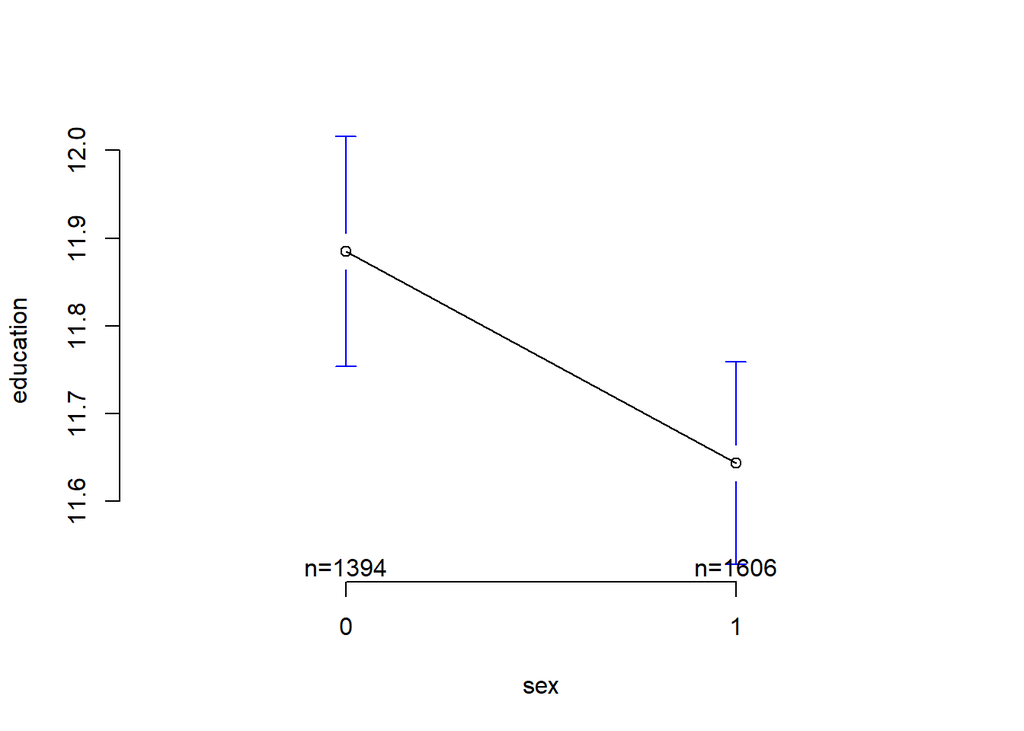

`plotmeans` nicely presents the number of observations and labels by default.

## Being Confident with Confidence (2 pt)

Dive into details about confidence calculation. Calculate CI of means by group:

$$CI = \mu \pm t \cdot \frac{\sigma}{\sqrt{n}} = \mu \pm t \cdot SE \approx \mu \pm 1.96 \cdot SE$$

Step by step, calculate the mean, standard deviation, number per group (gender) and standard error and store these measures in a `soep_2000_stats` dataframe. Guideline:

- In `soep_2000` data, use `group_by` on the gender variable `sex_factor` (connect them by the pipe operator `%>%`).
- Inside a `summarise` call, please calculate `mean(education)` and store it as `edu_mean`, calculate `sd(education)` and store it as `edu_sd` and calculate the number of observations via `n()` and store it as `count`.
- Pipe this into a `mutate()` command. Calculate the standard error `edu_se` as `edu_sd / sqrt(count)` and the lower and upper confidence interval as `edu_mean` plus or minus `qt(1 - (0.05 / 2), count - 1) * edu_se` and store it as `lower_ci` and `upper_ci`.

```r
# STRUCTURE IS GIVEN, PLEASE COMPLETE THE CODE
soep_2000_stats <- soep_2000 %>%
  group_by(XXX) %>%
  summarise(edu_mean = mean(XXX),
            edu_sd = sd(XXX),
             count = n()) %>%
  mutate(edu_se = XXXXXXX,
         lower_ci = XXXXXXX,
         upper_ci = XXXXXXX)

soep_2000_stats
```

Output should look like this:

```
## # A tibble: 2 x 7
##   sex_factor edu_mean edu_sd count edu_se lower_ci upper_ci
##   <fct>         <dbl>  <dbl> <int>  <dbl>    <dbl>    <dbl>
## 1 male           11.9   2.49  1394 0.0666     11.8     12.0
## 2 female         11.6   2.36  1606 0.0590     11.5     11.8
```

## One more time (2 pt)

…, we’re gonna celebRate (R.I.P. Daft Punk).

```r
ggplot(XXX, aes(x=XXX, y=XXX)) +
    geom_errorbar(aes(ymin=XXX, ymax=XXX), colour="black", width=.1) +
    geom_line() +
    geom_point(size=3, shape=21, fill="white") +
    xlab(XXX) +
    ylab(XXX) +
    ggtitle(XXX) +
    theme_bw()
```

The final plot should show the essential statistics as this:

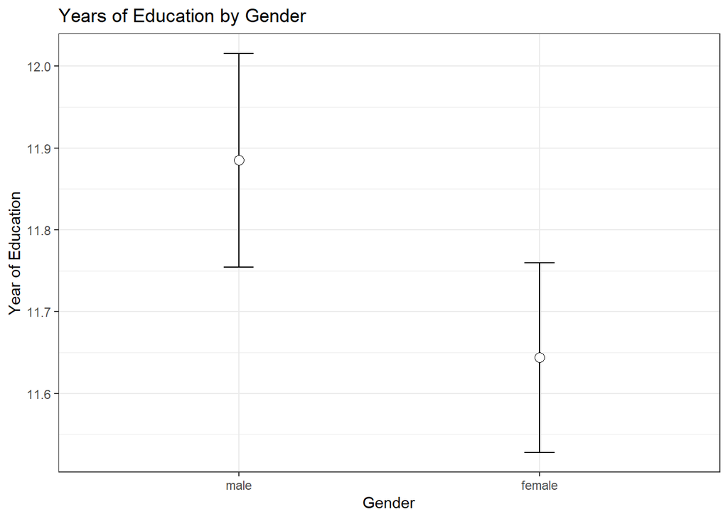

# Independence day

There is a one-liner to compare two means, the `t.test()`.

## A species from outer space (0 pt)

For the next calculation we focus on another sample: men. We apply `tidyverse` logic:

```r
men_before_after <- soep_no_na %>%
  filter(sex == 0) %>% # filter all males
  filter(year == 2000 | year == 2004) %>% # only use year 2000 or 2004
  group_by(id) %>% # do the subsequent command per person / id group
  filter(n() == 2) # only keep groups with exactly two observations/rows
```

There should be 1328 observations.

## Independent t-test (1 pt)

Run a `t.test()` on `satisf_org` versus `year` for the `men_before_after` data. Set `paired=FALSE`. This is called the *Welch Two Sample t-test*.

## Dependent t-test (1 pt)

Now run the `t.test()` with option `paired=TRUE`. The mean difference is exactly the same – can you see it? t-value, degree of freedom, p-value are different though …

## Does t stand for terror? (3 pt)

The formula on Wikipedia [Dependent t-test for paired samples](https://en.wikipedia.org/wiki/Student%27s_t-test#Dependent_t-test_for_paired_samples) comes as follows:

$$t = \frac{\bar{X}_D - \mu_0}{s_D/\sqrt n}$$
Please hard code the t-value formula for the dependent t-test in a programmatic way in R, i.e. calculate `t=7.5781` from its components. Please store all those values in R objects, i.e. never assign a number such as `n <- 100`. Print intermediate values and the final answer. Here is a suggestion for a work flow:

- Start from `men_before_after` data.
- Select columns `id`, `year` and `satisf_org` (relevant columns).
- Use `group_by()` by people.
- Calculate the differences of `satisf_org` in the paired sample (i.e. before/old - after/new). Call it `satis_diff` (1 pt). You can use a combination of `mutate()` and `lag()`. `lag()` moves a value to the next row. Hint: Since there are only 2 time points of observation per person, there can only be one difference.
- Use `ungroup()`.
- Calculate the number of pairs/people, store as `pairs_n` (0.5 pt).
- Calculate the mean of these differences, store as `pairs_mean` (0.5 pt).
- Calculate the standard deviation of the differences, store as `pairs_sd` (0.5 pt).
- Calculate the t-value according to the formula above (0.5 pt).

```r
options(pillar.sigfig=3) # shows more digits

# CODE STRUCUTRE TO COMPLETE
men_before_after %>%
  select(XXX) %>%
  group_by(XXX) %>%
  mutate(satis_diff = XXX - XXX) %>% #  before (old) - after (new)
  ungroup() %>%
  mutate(pairs_n = XXX,
         pairs_mean = mean(XXX, na.rm = TRUE),
         pairs_sd = sd(XXX, na.rm = TRUE),
         pairs_t = XXX)
```

```
## # A tibble: 1,328 x 8
##       id  year         satisf_org satis_diff pairs_n pairs_mean pairs_sd pairs_t
##    <dbl> <dbl>          <dbl+lbl>      <dbl>   <dbl>      <dbl>    <dbl>   <dbl>
##  1   457  2000 8 [8 Satisfied: O~         NA     664      0.535     1.82    7.58
##  2   457  2004 4 [4 Satisfied: O~          4     664      0.535     1.82    7.58
##  3  1044  2000 5 [5 Satisfied: O~         NA     664      0.535     1.82    7.58
##  4  1044  2004 7 [7 Satisfied: O~         -2     664      0.535     1.82    7.58
##  5  1596  2000 8 [8 Satisfied: O~         NA     664      0.535     1.82    7.58
##  6  1596  2004 2 [2 Satisfied: O~          6     664      0.535     1.82    7.58
##  7  1889  2000 8 [8 Satisfied: O~         NA     664      0.535     1.82    7.58
##  8  1889  2004 5 [5 Satisfied: O~          3     664      0.535     1.82    7.58
##  9  2241  2000 3 [3 Satisfied: O~         NA     664      0.535     1.82    7.58
## 10  2241  2004 5 [5 Satisfied: O~         -2     664      0.535     1.82    7.58
## # ... with 1,318 more rows
```

[^1]: In case you face a severe problem in the task before, you may copy the stat values from the previous table.